# Performing a GSEA Rank Test on Single Cell Data

Mark J Lawson

2025-10-14

The following is a tutorial on how to perform a GeneSet Enrichment Analysis (GSEA) rank test on single cell data using [`Seurat`](https://satijalab.org/seurat/), [`DESeq2`](https://bioconductor.org/packages/release/bioc/html/DESeq2.html), and the [`fGSEA`](https://bioconductor.org/packages/release/bioc/html/fgsea.html) packages. In a nutshell, we use methods to determine differentially expressed genes (DEGs) and use their resulting statistical metrics to rank the genes for a GSEA test.

This workflow details two approaches for generating DEGs for the rank test. The first uses the `FindMarkers()` function from `Seurat` and is ideal for simple comparisons where no batch effects are present. The second uses `DESeq2` in combination with aggregation of the cell-based expression to do a pseudobulk RNASeq differential expression analysis.

Both first require the following steps.

## Initializing the data

The following are the required packages.

```r
# packages for doing the analysis
library(Seurat) # For single cell analysis
library(SeuratData) # To get the example dataset
library(fgsea)  # Fast GSEA implementation
library(msigdbr)  # For gene sets
library(DESeq2) # For pseudo-bulk differential analysis
library(dplyr) # Tidy data manipulation
library(ggplot2) # Plotting tools
library(cowplot) # Combine plots
```

### Loading in the data

First we load in the `ifnb` dataset, which was originally generated as part of [this paper](https://www.nature.com/articles/nbt.4042) and used as an example in this [`Seurat` tutorial](https://satijalab.org/seurat/articles/integration_introduction). In this experiment, PBMCs were split into a stimulated and control group and the stimulated group was treated with interferon beta. This dataset is annotated with cells already having their cell types determined and can be pulled from the `SeuratData` package. Ultimately, we are going to see what genesets are being affected when we compare stimulated to control cells.

```r
# get data for doing analysis
InstallData("ifnb")

LoadData("ifnb") # load the data
```

```
## An object of class Seurat
## 14053 features across 13999 samples within 1 assay
## Active assay: RNA (14053 features, 0 variable features)
##  2 layers present: counts, data
```

```r
# Update old Seurat object to accommodate new features
ifnb <- UpdateSeuratObject(ifnb)
```

### Get Genesets

Here we use the `msigdbr` package to pull in the Hallmark genesets. Other collections like KEGG/Reactome or GO can be pulled by adjusting the `collection` and `subcollection` parameters. Here we are pulling the genesets for humans, but mouse data can be pulled in instead by either setting `species` to "Mus musculus" or `db_species` to "MM". The function `msigdbr_species()` lists the available options.

```r
# Get gene sets from MSigDB (e.g., Hallmark pathways)
gene_sets <- msigdbr(species = "Homo sapiens", collection = "H")
# Or use other collections:
# "C2" for curated gene sets (KEGG, Reactome, Wikipathways etc)
# "C5" for GO terms
# "C8" for cell type signatures

# Convert to list format for fgsea
pathways <- gene_sets %>%
  split(x = .$gene_symbol, f = .$gs_name)
```

## First approach: Simple comparison with FindMarkers

In situations where we do not have technical or biological replicates and thus are expecting no batch effects, we can split up the data by cell type and perform a comparison using the `Seurat` function `FindMarkers`. Ultimately we then have a list of differentially expressed genes and their corresponding metrics that can be fed into the GSEA rank test.

### Getting the DEGs

In this example, we are focusing specifically on one cell type (CD14 Mono). We then determine which genes show a difference between “STIM” (stimulated cells) and “CTRL” (control cells) using the wilcox test in `FindMarkers()`, although other tests can be used.

```r
Idents(ifnb) <- "seurat_annotations" # ensure that the idents are the cell types

# focus on one cell
ifnb_cd14 <- subset(ifnb, idents = "CD14 Mono")

# label cells with conditions
Idents(ifnb_cd14) <- "stim"
table(Idents(ifnb_cd14))
```

```
##
## CTRL STIM
## 2215 2147
```

```r
# find differentially expressed genes between markers
markers <- FindMarkers(
  ifnb_cd14,
  ident.1 = "STIM",
  ident.2 = "CTRL",
  test.use = "wilcox",  # or "MAST", "DESeq2"
  logfc.threshold = 0,  # Get all genes
  min.pct = 0.1
)
markers$gene_name <- rownames(markers) # make gene names a column in data frame

head(markers)
```

```
##         p_val avg_log2FC pct.1 pct.2 p_val_adj gene_name
## IFIT1       0   70.73672 0.985 0.033         0     IFIT1
## CXCL10      0  337.63562 0.984 0.035         0    CXCL10
## RSAD2       0   83.41584 0.988 0.045         0     RSAD2
## TNFSF10     0   82.23645 0.989 0.047         0   TNFSF10
## IFIT3       0   72.10004 0.992 0.056         0     IFIT3
## IFIT2       0   65.41976 0.961 0.039         0     IFIT2
```

### Performing GSEA on the ranked list

In order to perform the analysis and to give a directionality to the pathway enrichment, `fGSEA` requires a value that indicates both the significance of a gene’s differential expression and whether the gene is up-regulated or down-regulated. To do this, we take the `-log10` of the p-value and multiply it by the sign of the `log2` fold change. Also, since we have p-values of 0, we are replacing those values with the smallest non-zero value, to avoid results of `Inf` due to the `log10` of 0 being undefined. The resulting `stat` value is then used to rank the genes and then passed to `fGSEA`.

```r
# find minimum non-zero p-value
min_nz_pval <- min(markers$p_val[markers$p_val >0])

# create "stat" value for ranking
markers$stat <- -log10(pmax(markers$p_val, min_nz_pval)) * sign(markers$avg_log2FC)

# Create ranked gene list (by log fold change or stat)
# Important: remove NAs and sort
ranked_genes <- markers %>%
  filter(!is.na(stat) &
           !is.infinite(stat)) %>%
  arrange(desc(stat)) %>%
  pull(stat, name = gene_name)

# Run GSEA
fgsea_results <- fgsea(
  pathways = pathways,
  stats = ranked_genes,
  minSize = 15, # Minimal size of a gene set to test
  maxSize = 500 # Maximal size of a gene set to test
)

# output results
fgsea_results %>%
  arrange(padj) %>%
  head(5)
```

```
##                               pathway         pval         padj   log2err
##                                <char>        <num>        <num>     <num>
## 1: HALLMARK_INTERFERON_GAMMA_RESPONSE 1.110446e-16 4.330741e-15 1.0476265
## 2: HALLMARK_INTERFERON_ALPHA_RESPONSE 1.302071e-11 2.539038e-10 0.8753251
## 3: HALLMARK_OXIDATIVE_PHOSPHORYLATION 1.708996e-03 2.221694e-02 0.4550599
## 4:           HALLMARK_APICAL_JUNCTION 1.002038e-02 9.769874e-02 0.3807304
## 5:       HALLMARK_IL2_STAT5_SIGNALING 2.715819e-02 2.118339e-01 0.3524879
##            ES       NES  size  leadingEdge
##         <num>     <num> <int>       <list>
## 1:  0.8187772  1.939178   139 IFIT1, C....
## 2:  0.8431010  1.915748    79 CXCL10, ....
## 3: -0.5016359 -1.524877    91 ATP6V0B,....
## 4: -0.6778586 -1.710155    30 PFN1, VC....
## 5:  0.6530287  1.426891    53 CXCL10, ....
```

The results consist of genesets (that pass the given filtering thresholds) and their corresponding metrics. Important here is the `ES` value which shows the “enrichment score”. It reflects the degree to which a geneset is overrepresented at the top or bottom of a ranked list of genes (more info). It also indicates the overall directionality of the geneset with positive values indicating up-regulation and negative values indicating down-regulation. `NES` is a normalized version of that score, normalized to a mean enrichment of random samples of the same size [(more info)](https://www.gsea-msigdb.org/gsea/doc/GSEAUserGuideTEXT.htm#_Normalized_Enrichment_Score). `pval` and `padj` represent the raw significance of the enrichment and a BH-adjusted version of that p-value, respectively.

### Plotting the results

#### Table Plot

Using a table plot, we can better visualize the top (or whatever set of) genesets. It shows some of the metrics of the analysis, as well as visualizing the ranked gene list, showcasing why the geneset was called as being significant.

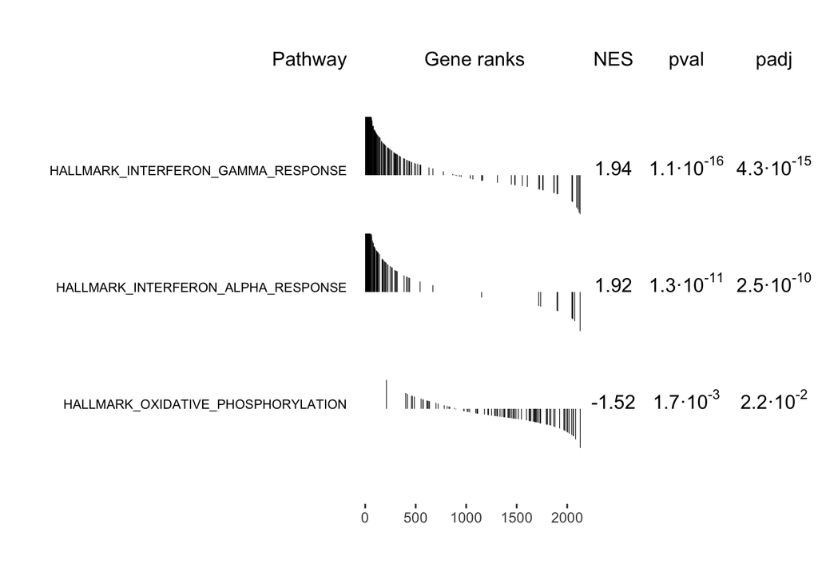

```r
# Table plot of top pathways
topPathways <- fgsea_results %>%
  filter(padj < 0.05) %>%
  arrange(desc(abs(NES))) %>%
  pull(pathway)

plotGseaTable(
  pathways[topPathways],
  ranked_genes,
  fgsea_results,
  gseaParam = 0.5,
  pathwayLabelStyle = list(size=8)
)
```

Here we see our 3 signficant genesets (at an FDR of 0.05), which includes two up-regulated and one down-regulated pathway. To get more details on the rankings that generated them, we can use …

#### Enrichment Plot

Through enrichment plots, we can better visualize how the enrichment score was generated by plotting it out in relation to the ranking of genes in a geneset. Here we showcase the difference between an up-regulated and down-regulated geneset.

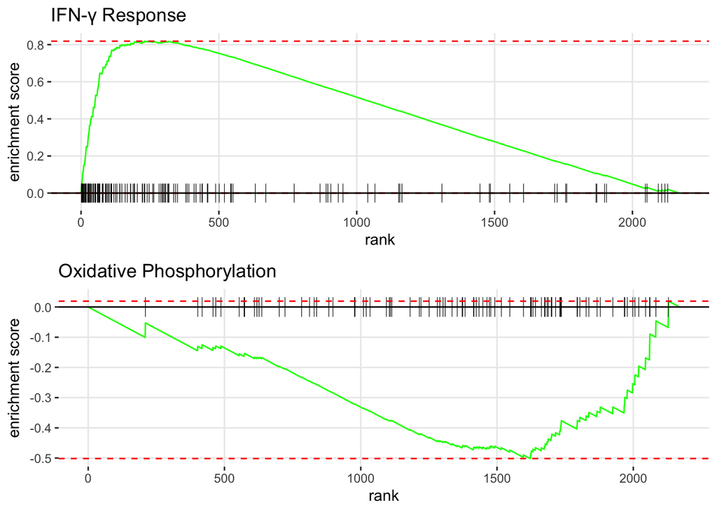

```r
# Plot enrichment for top pathway
p1 <- plotEnrichment(
  pathways[["HALLMARK_INTERFERON_GAMMA_RESPONSE"]],
  ranked_genes
) + labs(title = "IFN-γ Response")

p2 <- plotEnrichment(
  pathways[["HALLMARK_OXIDATIVE_PHOSPHORYLATION"]],
  ranked_genes
) + labs(title = "Oxidative Phosphorylation")

plot_grid(p1, p2, ncol=1)
```

## Second approach: Pseudo-bulk analysis using DESeq2

In situations where we expect the comparison to have to deal with batch effects, for instance due to biological or even technical replicates, a pseudobulk analysis using an RNASeq differential expression tool like `DESeq2` is a better option. The following section walks through doing that kind of analysis.

### Getting the DEGs

In order to create a set of “replicates” we will look at the differential expression between stimulated and control cells across two cell types: CD14 Mono and CD16 Mono. In the following code we aggregate the expression for each cell type and pull out the resulting cell types we want to work with. We further create metadata and use that to start the process of running `DESeq2`. After running through that workflow, and contrasting STIM to CTRL, we have a list of DEGs, ready for use in `fGSEA`.

```r
# aggregate cells to create "pseudobulk"
aggregate_ifnb <- AggregateExpression(ifnb, group.by = c("seurat_annotations", "stim"),
                                      return.seurat = TRUE)
Idents(aggregate_ifnb) <- "seurat_annotations"
agg_ifnb_cdmono <- subset(aggregate_ifnb, idents=c("CD14 Mono",
                                                   "CD16 Mono"))

# create metadata for samples
sample_metadata <- agg_ifnb_cdmono@meta.data %>%
  select(stim, seurat_annotations, orig.ident) %>%
  distinct() %>%
  as.data.frame()
rownames(sample_metadata) <- sample_metadata$orig.ident

head(sample_metadata)
```

```
##                stim seurat_annotations     orig.ident
## CD14 Mono_CTRL CTRL          CD14 Mono CD14 Mono_CTRL
## CD14 Mono_STIM STIM          CD14 Mono CD14 Mono_STIM
## CD16 Mono_CTRL CTRL          CD16 Mono CD16 Mono_CTRL
## CD16 Mono_STIM STIM          CD16 Mono CD16 Mono_STIM
```

```r
# create DESeq data set
dds <- DESeqDataSetFromMatrix(
  countData = agg_ifnb_cdmono[["RNA"]]$counts,
  colData = sample_metadata,
  design = ~ stim
)

# run DESeq
dds <- DESeq(dds)

# determine results of contrasting STIM vs CTRL samples
res <- results(dds, contrast = c("stim", "STIM", "CTRL"))

# reformat for extracting
res <- as.data.frame(res)
res$gene_name <- rownames(res)

head(res[order(res$padj),])
```

```
##         baseMean log2FoldChange     lfcSE     stat       pvalue         padj
## CXCL11  5693.183       8.507819 0.5538471 15.36131 2.974939e-53 2.525723e-49
## ISG15  70388.943       6.560922 0.5134575 12.77793 2.178006e-37 9.245634e-34
## DEFB1    727.629       6.472731 0.5514765 11.73709 8.226540e-32 2.328111e-28
## IFIT1   7711.616       6.948470 0.6192648 11.22051 3.233826e-29 6.863795e-26
## RSAD2   5659.016       6.736654 0.6207118 10.85311 1.927504e-27 3.272902e-24
## OASL    2273.690       4.452249 0.4147449 10.73491 6.978685e-27 9.874840e-24
##        gene_name
## CXCL11    CXCL11
## ISG15      ISG15
## DEFB1      DEFB1
## IFIT1      IFIT1
## RSAD2      RSAD2
## OASL        OASL
```

### Performing GSEA on the ranked list

Unlike with the `FindMarkers()` function, `DESeq2` gives us a signed ranking value we can use directly into `fGSEA`: `stat`. We can then rank the genes as we did with the previous analysis and run `fGSEA`.

```r
# Create ranked list
ranked_genes <- res %>%
  filter(!is.na(stat)) %>%
  arrange(desc(stat)) %>%
  pull(stat, name = gene_name)

# Run GSEA
fgsea_results <- fgsea(
  pathways = pathways,
  stats = ranked_genes,
  minSize = 15,
  maxSize = 500
)

# output results
fgsea_results %>%
  arrange(padj) %>%
  head(5)
```

```
##                               pathway         pval         padj   log2err
##                                <char>        <num>        <num>     <num>
## 1: HALLMARK_INTERFERON_GAMMA_RESPONSE 1.000000e-50 4.900000e-49        NA
## 2: HALLMARK_INTERFERON_ALPHA_RESPONSE 7.125911e-46 1.745848e-44 1.7624393
## 3:     HALLMARK_INFLAMMATORY_RESPONSE 2.661566e-09 4.347225e-08 0.7749390
## 4:                HALLMARK_COMPLEMENT 2.267307e-08 2.777451e-07 0.7337620
## 5: HALLMARK_OXIDATIVE_PHOSPHORYLATION 4.991389e-08 4.891561e-07 0.7195128
##            ES       NES  size  leadingEdge
##         <num>     <num> <int>       <list>
## 1:  0.8661461  2.918061   191 CXCL11, ....
## 2:  0.9134726  2.886607    93 CXCL11, ....
## 3:  0.5901638  1.975323   169 CXCL11, ....
## 4:  0.5800029  1.936951   163 IRF7, SE....
## 5: -0.4120766 -1.935689   180 NDUFAB1,....
```

```r
fgsea_results %>%
  arrange(padj) %>%
  tail(5)
```

```
##                        pathway      pval      padj    log2err         ES
##                         <char>     <num>     <num>      <num>      <num>
## 1:   HALLMARK_MTORC1_SIGNALING 0.6652720 0.7244073 0.03456643  0.2716777
## 2: HALLMARK_HEDGEHOG_SIGNALING 0.7128571 0.7593478 0.04577045  0.3293457
## 3:     HALLMARK_UV_RESPONSE_DN 0.7582781 0.7905453 0.03084682  0.2591534
## 4:        HALLMARK_E2F_TARGETS 0.7895833 0.8060330 0.02583317  0.2504684
## 5:    HALLMARK_NOTCH_SIGNALING 0.8443580 0.8443580 0.08679498 -0.2333848
##           NES  size  leadingEdge
##         <num> <int>       <list>
## 1:  0.9096071   183 PSMA4, P....
## 2:  0.8109045    20          PML
## 3:  0.8300572   106 CACNA1A,....
## 4:  0.8381129   179 LMNB1, D....
## 5: -0.7869075    28 PPARD, A....
```

Here we also showcase both the top genesets and the bottom genesets, in terms of significance.

### Plotting the results

#### Table Plot

As before, a table plot is a nice balance between raw metrics and visualization of the ranked set of genes that led to the genesets being labeled as significant.

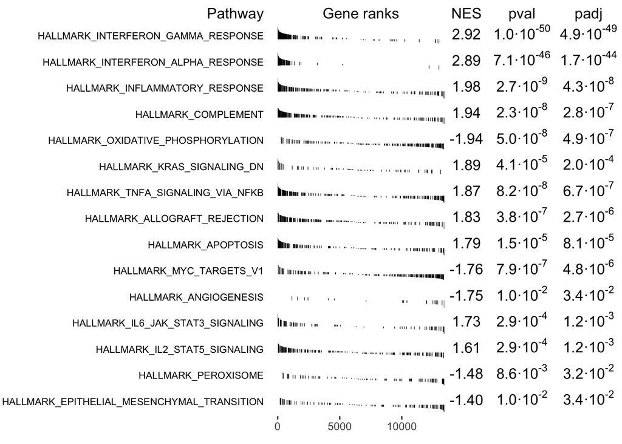

```r
# Table plot of top pathways
topPathways <- fgsea_results %>%
  filter(padj < 0.05) %>%
  arrange(desc(abs(NES))) %>%
  pull(pathway)

plotGseaTable(
  pathways[topPathways],
  ranked_genes,
  fgsea_results,
  gseaParam = 0.5,
  pathwayLabelStyle = list(size=8)
)
```

#### Enrichment Plot

For this set of enrichment plots, we are showing the contrast between something being significant (first plot) and not significant (second plot). As we can see, unlike the first plot, the second plot never reaches a high enrichment score in either the negative or positive direction. This is further demonstrated by the even distribution of the gene rankins.

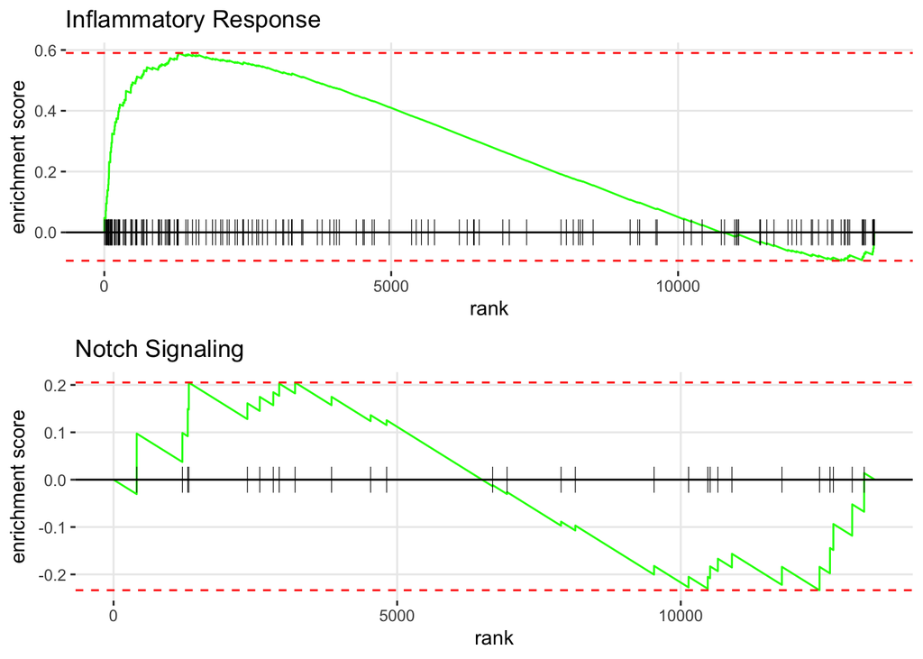

```r
# compare top pathway to bottom pathway
p1 <- plotEnrichment(
  pathways[["HALLMARK_INFLAMMATORY_RESPONSE"]],
  ranked_genes
) + labs(title = "Inflammatory Response")

p2 <- plotEnrichment(
  pathways[["HALLMARK_NOTCH_SIGNALING"]],
  ranked_genes
) + labs(title = "Notch Signaling")

plot_grid(p1, p2, ncol=1)
```